**ANOMALY DETECTION**

```python
#importing required packages
import pandas as pd
import numpy as np
import matplotlib.pyplot as plt
from sklearn.model_selection import train_test_split
from sklearn.ensemble import IsolationForest
from sklearn.neighbors import LocalOutlierFactor
from sklearn import svm
from sklearn.base import BaseEstimator, TransformerMixin
from scipy.stats import chi2_contingency
```

```python
#download dataset
df = pd.read_csv('navigation_records.csv')
```

**VISUALIZATION**

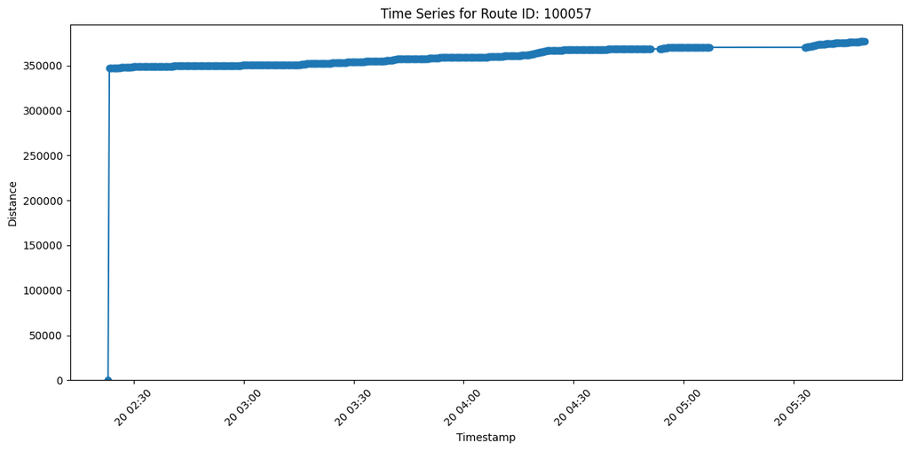

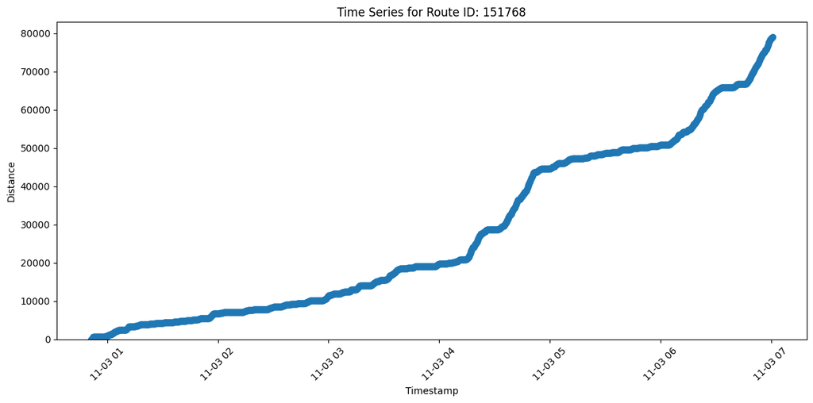

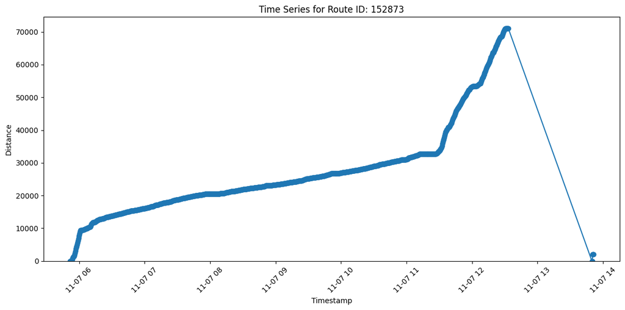

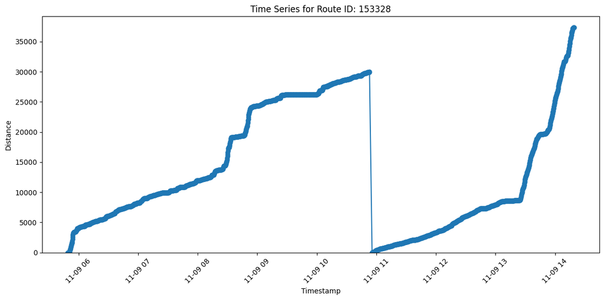

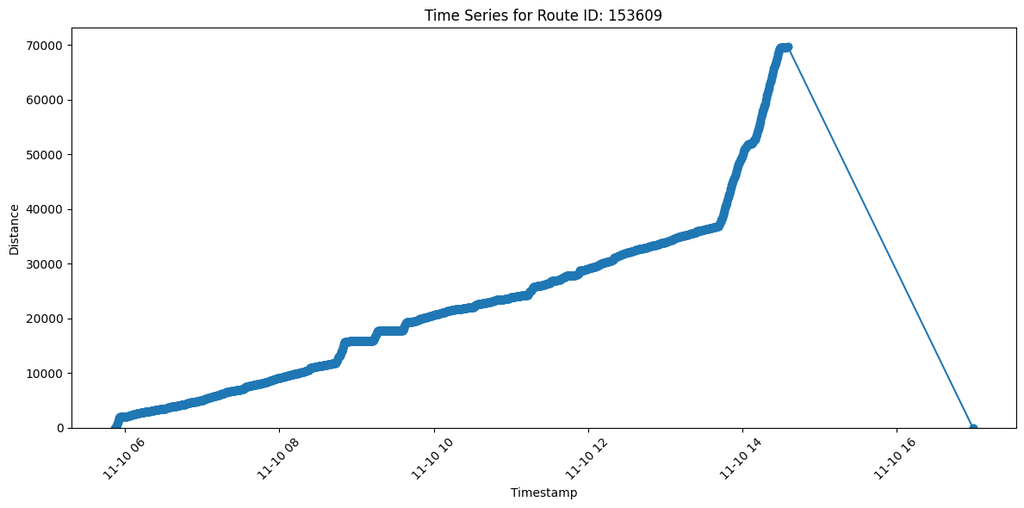

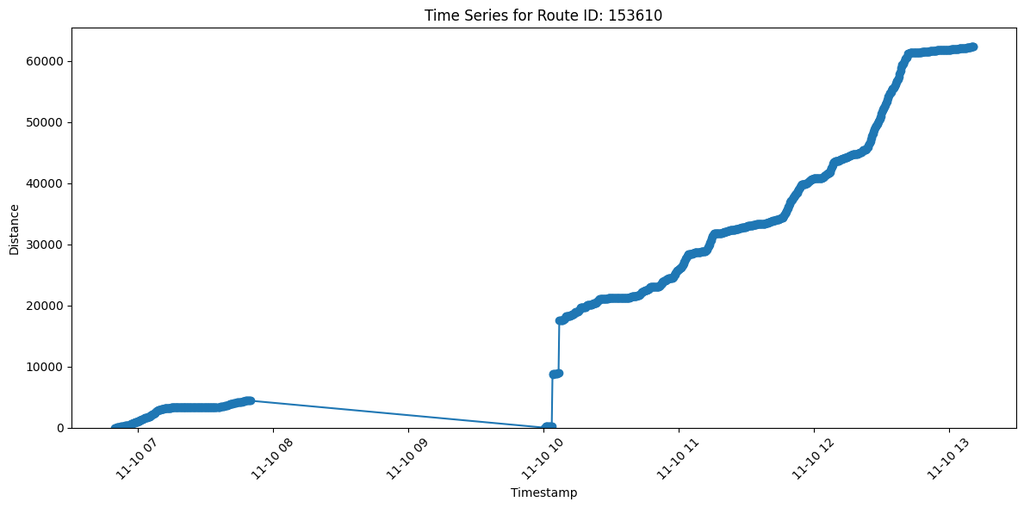

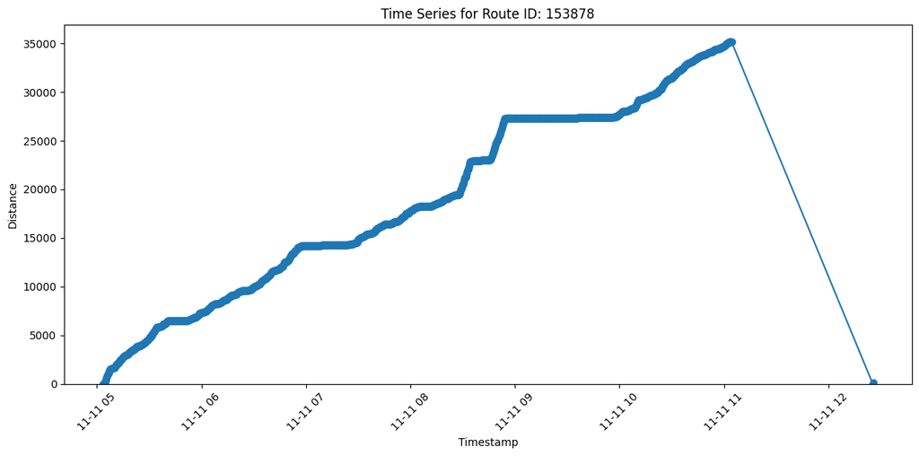

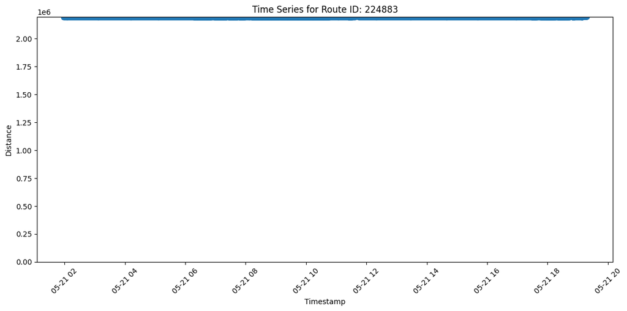

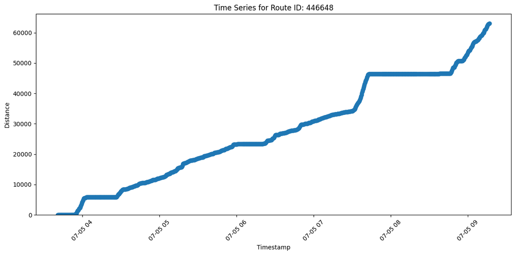

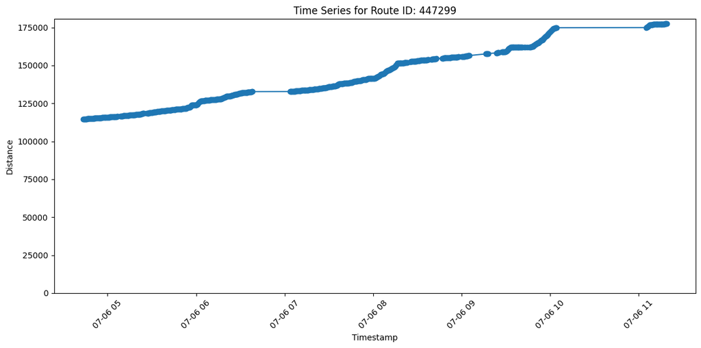

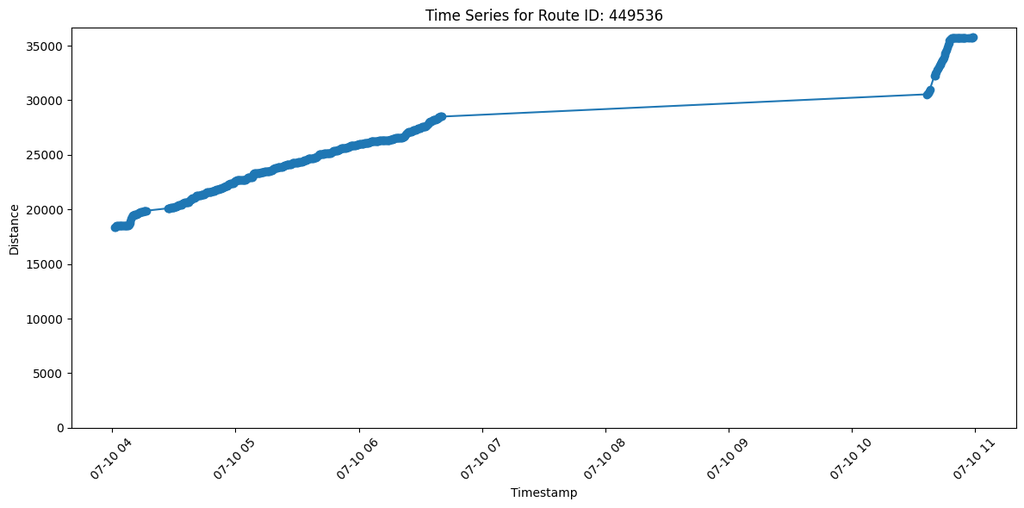

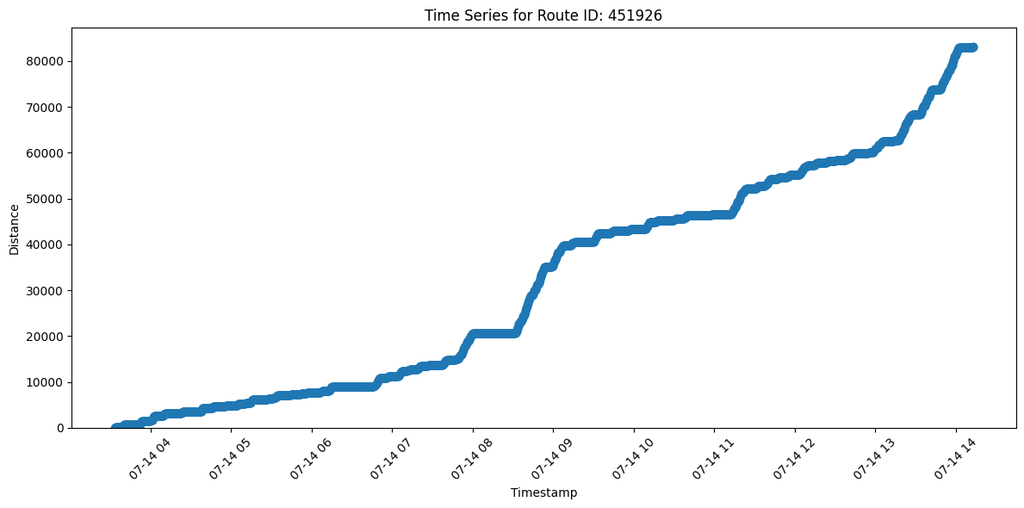

[8 more figures not shown]

```python
#visualizing data for each route_id group
df['recorded_at'] = pd.to_datetime(df['recorded_at'])

groups = df.groupby('route_id')

for route_id, group in groups:
    group = group.sort_values('recorded_at')

    fig, ax = plt.subplots(figsize=(12, 6))
    ax.plot(group['recorded_at'], group['distance'], marker='o', linestyle='-')
    ax.set_title(f'Time Series for Route ID: {route_id}')
    ax.set_xlabel('Timestamp')
    ax.set_ylabel('Distance')
    ax.set_ylim(bottom=0)
    plt.xticks(rotation=45)
    plt.tight_layout()
    plt.savefig(f'timeseries_route_{route_id}.png')
    plt.show()
    plt.close(fig)
```

```python
#making some required calculations beforehand

df['distance'] = df['distance'].astype(float)

df = df.sort_values(by=['route_id', 'recorded_at'])

df['lag_distance'] = df.groupby('route_id')['distance'].shift(1)

df['change_flag'] = (df['lag_distance'] > df['distance']).astype(int)

df['last_record_flag'] = (df['recorded_at'] == df.groupby('route_id')['recorded_at'].transform('max')).astype(int)
df['first_record_flag'] = (df['recorded_at'] == df.groupby('route_id')['recorded_at'].transform('min')).astype(int)

to_last_calc = df[(df['change_flag'] == 1) | (df['last_record_flag'] == 1) | (df['first_record_flag'] == 1)].copy()

to_last_calc['to_sum'] = to_last_calc.apply(
    lambda row: row['lag_distance'] if row['change_flag'] == 1
    else (row['distance'] if (row['first_record_flag'] == 1 or row['last_record_flag'] == 1) else None), axis=1)

to_last_calc['rn'] = to_last_calc.groupby('route_id').cumcount() + 1
to_last_calc['starts_with_zero'] = (to_last_calc.groupby('route_id')['distance'].transform('min') == 0).replace({True: 'yes', False: 'no'})
to_last_calc['min_dist'] = to_last_calc.groupby('route_id')['distance'].transform('min')

to_last_calc['consistent_starts_with_zero'] = to_last_calc.groupby('route_id')['starts_with_zero'].transform(lambda x: x.max())

to_last_calc['cumulative_sums'] = to_last_calc.apply(
    lambda row: row['distance'] - row['min_dist'] if (row['starts_with_zero'] == 'no' and (row['rn'] == 1 or row['rn'] == 2))
    else row['to_sum'], axis=1)

final_result = to_last_calc.sort_values(by=['route_id', 'recorded_at'], ascending=[True, False])
```

**Further Visualizations**

It seems that there are only 7 anomaly points in 30337 records covering *0.02%* of entire data.

```
        Condition  Count  Percentage
0    Total Points  30337  100.000000
1  Anomaly Points      7    0.023074
```

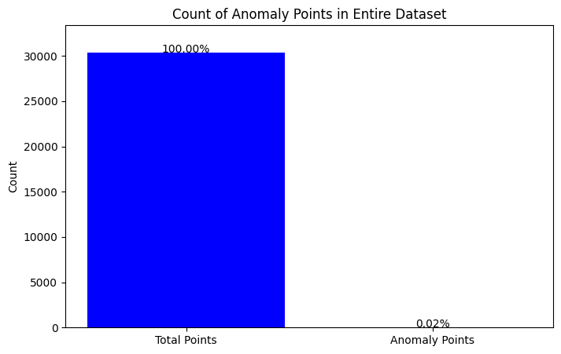

```python
# Calculate total points and points with change_flag = 1
total_points = len(df)
change_flag_points = len(df[df['change_flag'] == 1])

# Calculate percentage
percentage_change_flag = (change_flag_points / total_points) * 100 if total_points > 0 else 0

# Create a summary DataFrame
summary_df = pd.DataFrame({
    'Condition': ['Total Points', 'Anomaly Points'],
    'Count': [total_points, change_flag_points],
    'Percentage': [100, percentage_change_flag]
})

# Display the summary table
print(summary_df)

# Visualization
plt.figure(figsize=(8, 5))
plt.bar(summary_df['Condition'], summary_df['Count'], color=['blue', 'orange'])
plt.ylabel('Count')
plt.title('Count of Anomaly Points in Entire Dataset')
plt.ylim(0, total_points * 1.1)

# Show percentages on top of the bars
for i, row in summary_df.iterrows():
    plt.text(i, row['Count'] + 0.5, f"{row['Percentage']:.2f}%", ha='center')

plt.show()
```

Let's make some further visualizations for the dataaset. From 7 anomaly points, 6 of them happened at weekday and 1 at weekend. At that point, there is not enough data to make any reasonable inference. In addition, 2 of them happened at around 10:00 and others scatter around the days. Again, due to the limited amount of data, it is hard to determine any reasonable distribution.

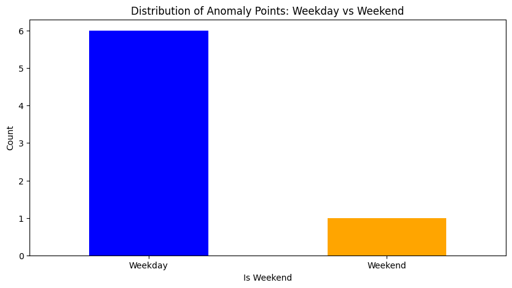

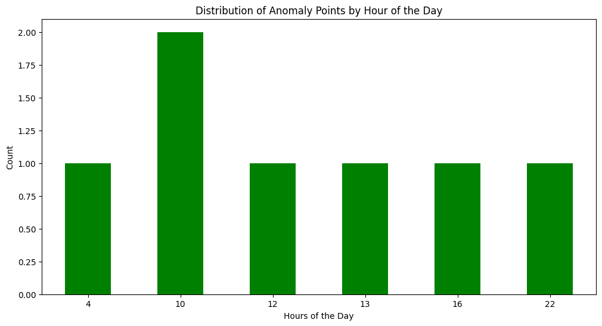

```python
df['is_weekend'] = df['recorded_at'].dt.dayofweek >= 5
df['hour'] = df['recorded_at'].dt.hour

change_flag_weekend_count = df[df['change_flag'] == 1]['is_weekend'].value_counts()
change_flag_hourly_count = df[df['change_flag'] == 1]['hour'].value_counts().sort_index()

plt.figure(figsize=(10, 5))
change_flag_weekend_count.plot(kind='bar', color=['blue', 'orange'])
plt.title('Distribution of Anomaly Points: Weekday vs Weekend')
plt.xlabel('Is Weekend')
plt.ylabel('Count')
plt.xticks(ticks=[0, 1], labels=['Weekday', 'Weekend'], rotation=0)
plt.show()

plt.figure(figsize=(12, 6))
change_flag_hourly_count.plot(kind='bar', color='green')
plt.title('Distribution of Anomaly Points by Hour of the Day')
plt.xlabel('Hours of the Day')
plt.ylabel('Count')
plt.xticks(rotation=0)
plt.show()
```

**Chi-Squire Test**

Although most recommend that chi-squire test not be used if the sample size is less than 50, let's apply that to our data and see what we'll get. If we want to be rigorous, considering applying statistical tests (e.g. Chi-squared test) is important to assess the significance of any patterns we find. The test results are printed, which include the Chi-squared statistic and the p-value. A low p-value < 0.05 indicates a significant association between anomaly and the categorical variable. Since p-value = 1 > 0.5, we can say that result is insignificant, there is no relationship between anomaly points and whether it is weekend or weekday.

```python
contingency_weekend = pd.crosstab(df['is_weekend'], df['change_flag'])

chi2_weekend, p_weekend, dof_weekend, expected_weekend = chi2_contingency(contingency_weekend)

print("Chi-squared Test for Weekend vs. Weekday:")
print(f"Chi-squared Statistic: {chi2_weekend}")
print(f"P-value: {p_weekend}")
print(f"Degrees of Freedom: {dof_weekend}")
print("Expected Frequencies:\n", expected_weekend)
```

```
Chi-squared Test for Weekend vs. Weekday:
Chi-squared Statistic: 0.0
P-value: 1.0
Degrees of Freedom: 1
Expected Frequencies:
 [[2.70557557e+04 6.24432211e+00]
 [3.27424432e+03 7.55677885e-01]]
```